# Russian_brand_sales_and_marketing_analysis

## Russian brand sales and marketing analysis.

### Research Question.

Kira Plastinina (Links to an external site.) is a Russian brand that is sold through a defunct chain of retail stores in Russia, Ukraine, Kazakhstan, Belarus, China, Philippines, and Armenia. The brand’s Sales and Marketing team would like to understand their customer’s behavior from data that they have collected over the past year.

Libraries

```r
install.packages('data.table')
install.packages('caret')
install.packages('psych')
install.packages('Amelia')
install.packages('mice')
install.packages('GGally')
install.packages('rpart')
install.packages('randomForest')
library(tidyverse)
library(data.table)
```

```r
library(ggplot2)
library(caret)
library(psych)
library(Amelia)
library(mice)
library(GGally)
library(rpart)
library(randomForest)
ecommerce <- read.csv('http://bit.ly/EcommerceCustomersDataset')
head(ecommerce)
```

```
##   Administrative Administrative_Duration Informational Informational_Duration
## 1              0                       0             0                      0
## 2              0                       0             0                      0
## 3              0                      -1             0                     -1
## 4              0                       0             0                      0
## 5              0                       0             0                      0
## 6              0                       0             0                      0
##   ProductRelated ProductRelated_Duration BounceRates ExitRates PageValues
## 1              1                0.000000  0.20000000 0.2000000          0
## 2              2               64.000000  0.00000000 0.1000000          0
## 3              1               -1.000000  0.20000000 0.2000000          0
## 4              2                2.666667  0.05000000 0.1400000          0
## 5             10              627.500000  0.02000000 0.0500000          0
## 6             19              154.216667  0.01578947 0.0245614          0
##   SpecialDay Month OperatingSystems Browser Region TrafficType
## 1          0   Feb                1       1      1           1
## 2          0   Feb                2       2      1           2
## 3          0   Feb                4       1      9           3
## 4          0   Feb                3       2      2           4
## 5          0   Feb                3       3      1           4
## 6          0   Feb                2       2      1           3
##         VisitorType Weekend Revenue
## 1 Returning_Visitor   FALSE   FALSE
## 2 Returning_Visitor   FALSE   FALSE
## 3 Returning_Visitor   FALSE   FALSE
## 4 Returning_Visitor   FALSE   FALSE
## 5 Returning_Visitor    TRUE   FALSE
## 6 Returning_Visitor   FALSE   FALSE
```

###### data structure

```r
str(ecommerce)
```

```
## 'data.frame':    12330 obs. of  18 variables:
##  $ Administrative         : int  0 0 0 0 0 0 0 1 0 0 ...
##  $ Administrative_Duration: num  0 0 -1 0 0 0 -1 -1 0 0 ...
##  $ Informational          : int  0 0 0 0 0 0 0 0 0 0 ...
##  $ Informational_Duration : num  0 0 -1 0 0 0 -1 -1 0 0 ...
##  $ ProductRelated         : int  1 2 1 2 10 19 1 1 2 3 ...
##  $ ProductRelated_Duration: num  0 64 -1 2.67 627.5 ...
##  $ BounceRates            : num  0.2 0 0.2 0.05 0.02 ...
##  $ ExitRates              : num  0.2 0.1 0.2 0.14 0.05 ...
##  $ PageValues             : num  0 0 0 0 0 0 0 0 0 0 ...
##  $ SpecialDay             : num  0 0 0 0 0 0 0.4 0 0.8 0.4 ...
##  $ Month                  : chr  "Feb" "Feb" "Feb" "Feb" ...
##  $ OperatingSystems       : int  1 2 4 3 3 2 2 1 2 2 ...
##  $ Browser                : int  1 2 1 2 3 2 4 2 2 4 ...
##  $ Region                 : int  1 1 9 2 1 1 3 1 2 1 ...
##  $ TrafficType            : int  1 2 3 4 4 3 3 5 3 2 ...
##  $ VisitorType            : chr  "Returning_Visitor" "Returning_Visitor" "Returning_Visitor" "Returning_Visitor" ...
##  $ Weekend                : logi  FALSE FALSE FALSE FALSE TRUE FALSE ...
##  $ Revenue                : logi  FALSE FALSE FALSE FALSE FALSE FALSE ...
```

###### Preview

```r
head(ecommerce, 6)
```

```
##   Administrative Administrative_Duration Informational Informational_Duration
## 1              0                       0             0                      0
## 2              0                       0             0                      0
## 3              0                      -1             0                     -1
## 4              0                       0             0                      0
## 5              0                       0             0                      0
## 6              0                       0             0                      0
##   ProductRelated ProductRelated_Duration BounceRates ExitRates PageValues
## 1              1                0.000000  0.20000000 0.2000000          0
## 2              2               64.000000  0.00000000 0.1000000          0
## 3              1               -1.000000  0.20000000 0.2000000          0
## 4              2                2.666667  0.05000000 0.1400000          0
## 5             10              627.500000  0.02000000 0.0500000          0
## 6             19              154.216667  0.01578947 0.0245614          0
##   SpecialDay Month OperatingSystems Browser Region TrafficType
## 1          0   Feb                1       1      1           1
## 2          0   Feb                2       2      1           2
## 3          0   Feb                4       1      9           3
## 4          0   Feb                3       2      2           4
## 5          0   Feb                3       3      1           4
## 6          0   Feb                2       2      1           3
##         VisitorType Weekend Revenue
## 1 Returning_Visitor   FALSE   FALSE
## 2 Returning_Visitor   FALSE   FALSE
## 3 Returning_Visitor   FALSE   FALSE
## 4 Returning_Visitor   FALSE   FALSE
## 5 Returning_Visitor    TRUE   FALSE
## 6 Returning_Visitor   FALSE   FALSE
```

##### last 6 entries of the dataset

```r
tail(ecommerce, 6)
```

```
##       Administrative Administrative_Duration Informational
## 12325              0                       0             1
## 12326              3                     145             0
## 12327              0                       0             0
## 12328              0                       0             0
## 12329              4                      75             0
## 12330              0                       0             0
##       Informational_Duration ProductRelated ProductRelated_Duration BounceRates
## 12325                      0             16                 503.000 0.000000000
## 12326                      0             53                1783.792 0.007142857
## 12327                      0              5                 465.750 0.000000000
## 12328                      0              6                 184.250 0.083333333
## 12329                      0             15                 346.000 0.000000000
## 12330                      0              3                  21.250 0.000000000
##        ExitRates PageValues SpecialDay Month OperatingSystems Browser Region
## 12325 0.03764706    0.00000          0   Nov                2       2      1
## 12326 0.02903061   12.24172          0   Dec                4       6      1
## 12327 0.02133333    0.00000          0   Nov                3       2      1
## 12328 0.08666667    0.00000          0   Nov                3       2      1
## 12329 0.02105263    0.00000          0   Nov                2       2      3
## 12330 0.06666667    0.00000          0   Nov                3       2      1
##       TrafficType       VisitorType Weekend Revenue
## 12325           1 Returning_Visitor   FALSE   FALSE
## 12326           1 Returning_Visitor    TRUE   FALSE
## 12327           8 Returning_Visitor    TRUE   FALSE
## 12328          13 Returning_Visitor    TRUE   FALSE
## 12329          11 Returning_Visitor   FALSE   FALSE
## 12330           2       New_Visitor    TRUE   FALSE
```

##### check for data description

```r
summary(ecommerce)
```

```
##  Administrative   Administrative_Duration Informational
##  Min.   : 0.000   Min.   :  -1.00         Min.   : 0.000
##  1st Qu.: 0.000   1st Qu.:   0.00         1st Qu.: 0.000
##  Median : 1.000   Median :   8.00         Median : 0.000
##  Mean   : 2.318   Mean   :  80.91         Mean   : 0.504
##  3rd Qu.: 4.000   3rd Qu.:  93.50         3rd Qu.: 0.000
##  Max.   :27.000   Max.   :3398.75         Max.   :24.000
##  NA's   :14       NA's   :14              NA's   :14
##  Informational_Duration ProductRelated   ProductRelated_Duration
##  Min.   :  -1.00        Min.   :  0.00   Min.   :   -1.0
##  1st Qu.:   0.00        1st Qu.:  7.00   1st Qu.:  185.0
##  Median :   0.00        Median : 18.00   Median :  599.8
##  Mean   :  34.51        Mean   : 31.76   Mean   : 1196.0
##  3rd Qu.:   0.00        3rd Qu.: 38.00   3rd Qu.: 1466.5
##  Max.   :2549.38        Max.   :705.00   Max.   :63973.5
##  NA's   :14             NA's   :14       NA's   :14
##   BounceRates         ExitRates         PageValues        SpecialDay
##  Min.   :0.000000   Min.   :0.00000   Min.   :  0.000   Min.   :0.00000
##  1st Qu.:0.000000   1st Qu.:0.01429   1st Qu.:  0.000   1st Qu.:0.00000
##  Median :0.003119   Median :0.02512   Median :  0.000   Median :0.00000
##  Mean   :0.022152   Mean   :0.04300   Mean   :  5.889   Mean   :0.06143
##  3rd Qu.:0.016684   3rd Qu.:0.05000   3rd Qu.:  0.000   3rd Qu.:0.00000
##  Max.   :0.200000   Max.   :0.20000   Max.   :361.764   Max.   :1.00000
##  NA's   :14         NA's   :14
##     Month           OperatingSystems    Browser           Region
##  Length:12330       Min.   :1.000    Min.   : 1.000   Min.   :1.000
##  Class :character   1st Qu.:2.000    1st Qu.: 2.000   1st Qu.:1.000
##  Mode  :character   Median :2.000    Median : 2.000   Median :3.000
##                     Mean   :2.124    Mean   : 2.357   Mean   :3.147
##                     3rd Qu.:3.000    3rd Qu.: 2.000   3rd Qu.:4.000
##                     Max.   :8.000    Max.   :13.000   Max.   :9.000
##
##   TrafficType    VisitorType         Weekend         Revenue
##  Min.   : 1.00   Length:12330       Mode :logical   Mode :logical
##  1st Qu.: 2.00   Class :character   FALSE:9462      FALSE:10422
##  Median : 2.00   Mode  :character   TRUE :2868      TRUE :1908
##  Mean   : 4.07
##  3rd Qu.: 4.00
##  Max.   :20.00
##
```

##### checking for size and shape of dataframe

```r
dim(ecommerce)
```

```
## [1] 12330    18
```

### Data Preprocessing.

#### i. Completeness

This is achieved by checking for missing values if any imputed to ensure correct predictions are made.

```r
total_null <- sum(is.na(ecommerce))
total_null
```

```
## [1] 112
```

##### missing values per column.

```r
lapply(ecommerce, function(x) sum(is.na(x)))
```

```
## $Administrative
## [1] 14
##
## $Administrative_Duration
## [1] 14
##
## $Informational
## [1] 14
##
## $Informational_Duration
## [1] 14
##
## $ProductRelated
## [1] 14
##
## $ProductRelated_Duration
## [1] 14
##
## $BounceRates
## [1] 14
##
## $ExitRates
## [1] 14
##
## $PageValues
## [1] 0
##
## $SpecialDay
## [1] 0
##
## $Month
## [1] 0
##
## $OperatingSystems
## [1] 0
##
## $Browser
## [1] 0
##
## $Region
## [1] 0
##
## $TrafficType
## [1] 0
##
## $VisitorType
## [1] 0
##
## $Weekend
## [1] 0
##
## $Revenue
## [1] 0
```

Percentage per column

```r
pMiss <- function(x){sum(is.na(x))/length(x)*100}
apply(ecommerce,2,pMiss)
```

```
##          Administrative Administrative_Duration           Informational
##               0.1135442               0.1135442               0.1135442
##  Informational_Duration          ProductRelated ProductRelated_Duration
##               0.1135442               0.1135442               0.1135442
##             BounceRates               ExitRates              PageValues
##               0.1135442               0.1135442               0.0000000
##              SpecialDay                   Month        OperatingSystems
##               0.0000000               0.0000000               0.0000000
##                 Browser                  Region             TrafficType
##               0.0000000               0.0000000               0.0000000
##             VisitorType                 Weekend                 Revenue
##               0.0000000               0.0000000               0.0000000
```

```r
apply(ecommerce,1,pMiss)
```

[output not shown]

[output cut: 1527 more lines]

```r
ecommerce1$imp$Administrative
```

```
##       1 2  3 4  5
## 1066  0 3  1 1  1
## 1133  0 0  1 0  0
## 1134  0 0  0 0  2
## 1135  0 2  4 0  0
## 1136 13 2  0 4  2
## 1137  1 0  0 0  0
## 1474  0 0  0 1  0
## 1475  0 0  0 0  0
## 1476  3 0  0 0  5
## 1477  0 2  5 0 23
## 2038  0 0  1 0  1
## 2039  1 0  4 3  9
## 2040  0 0  3 0  3
## 2754  1 4 10 0  0
```

```r
ecommerce1 <- complete(ecommerce1, 1)
head(ecommerce1,6)
```

```
##   Administrative Administrative_Duration Informational Informational_Duration
## 1              0                       0             0                      0
## 2              0                       0             0                      0
## 3              0                      -1             0                     -1
## 4              0                       0             0                      0
## 5              0                       0             0                      0
## 6              0                       0             0                      0
##   ProductRelated ProductRelated_Duration BounceRates ExitRates PageValues
## 1              1                0.000000  0.20000000 0.2000000          0
## 2              2               64.000000  0.00000000 0.1000000          0
## 3              1               -1.000000  0.20000000 0.2000000          0
## 4              2                2.666667  0.05000000 0.1400000          0
## 5             10              627.500000  0.02000000 0.0500000          0
## 6             19              154.216667  0.01578947 0.0245614          0
##   SpecialDay Month OperatingSystems Browser Region TrafficType
## 1          0   Feb                1       1      1           1
## 2          0   Feb                2       2      1           2
## 3          0   Feb                4       1      9           3
## 4          0   Feb                3       2      2           4
## 5          0   Feb                3       3      1           4
## 6          0   Feb                2       2      1           3
##         VisitorType Weekend Revenue
## 1 Returning_Visitor   FALSE   FALSE
## 2 Returning_Visitor   FALSE   FALSE
## 3 Returning_Visitor   FALSE   FALSE
## 4 Returning_Visitor   FALSE   FALSE
## 5 Returning_Visitor    TRUE   FALSE
## 6 Returning_Visitor   FALSE   FALSE
```

checking if there are anymore missing values

```r
lapply(ecommerce1, function(x) sum(is.na(x)))
```

```
## $Administrative
## [1] 0
##
## $Administrative_Duration
## [1] 0
##
## $Informational
## [1] 0
##
## $Informational_Duration
## [1] 0
##
## $ProductRelated
## [1] 0
##
## $ProductRelated_Duration
## [1] 0
##
## $BounceRates
## [1] 0
##
## $ExitRates
## [1] 0
##
## $PageValues
## [1] 0
##
## $SpecialDay
## [1] 0
##
## $Month
## [1] 0
##
## $OperatingSystems
## [1] 0
##
## $Browser
## [1] 0
##
## $Region
## [1] 0
##
## $TrafficType
## [1] 0
##
## $VisitorType
## [1] 0
##
## $Weekend
## [1] 0
##
## $Revenue
## [1] 0
```

####ii. Cosistency. Consistency of values in a dataset is achieved when there are do duplicated entries in the data.

```r
duplicated_rows <- ecommerce1[duplicated(ecommerce1), ]
duplicated_rows
```

```
##       Administrative Administrative_Duration Informational
## 159                0                       0             0
## 179                0                       0             0
## 419                0                       0             0
## 457                0                       0             0
## 484                0                       0             0
## 513                0                       0             0
## 555                0                       0             0
## 590                0                       0             0
## 660                0                       0             0
## 775                0                       0             0
## 873                0                       0             0
## 890                0                       0             0
## 923                0                       0             0
## 948                0                       0             0
```

[output cut: 457 more lines]

##### iii. Relevance.

This is achieved by ensuring all columns/ features provided for the analysis are relevant to the study.

##### iv. Accuracy.

Achieved by checking all entries are correct.

Outliers.

```r
colnames(ecommerce1)
```

```
##  [1] "Administrative"          "Administrative_Duration"
##  [3] "Informational"           "Informational_Duration"
##  [5] "ProductRelated"          "ProductRelated_Duration"
##  [7] "BounceRates"             "ExitRates"
##  [9] "PageValues"              "SpecialDay"
## [11] "Month"                   "OperatingSystems"
## [13] "Browser"                 "Region"
## [15] "TrafficType"             "VisitorType"
## [17] "Weekend"                 "Revenue"
```

Using Boxplots to check for outliers.

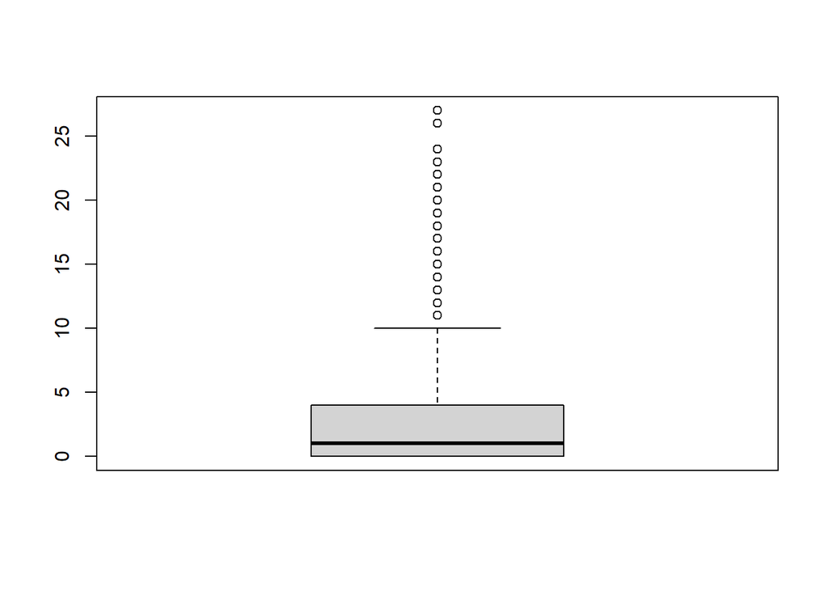

```
##   [1] 12 16 13 11 13 18 14 12 12 16 13 17 19 15 11 11 12 13 11 14 11 15 13 11 11
##  [26] 11 12 11 24 11 11 14 14 12 13 12 13 13 13 15 12 15 11 11 14 11 12 19 24 12
##  [51] 12 14 12 11 14 11 14 12 13 11 12 17 16 15 11 12 11 15 12 11 14 16 12 11 12
##  [76] 14 13 15 11 13 11 11 17 15 15 14 16 13 22 13 15 12 11 11 16 13 12 12 11 24
## [101] 13 18 12 12 17 15 11 17 13 16 13 18 17 11 24 12 11 15 12 16 11 11 11 12 14
## [126] 12 15 11 12 13 12 11 14 15 11 12 12 14 16 11 12 15 11 21 11 11 11 11 13 15
## [151] 11 14 14 15 13 14 18 16 15 13 19 20 12 18 12 12 12 13 13 14 13 19 11 11 11
## [176] 11 14 11 11 14 17 11 14 13 13 16 13 13 13 11 11 11 16 15 12 15 12 11 18 13
## [201] 14 13 11 15 15 11 13 16 12 14 14 11 15 19 11 14 23 16 14 15 16 14 11 14 11
## [226] 13 15 23 13 11 12 11 11 12 12 17 12 11 12 15 12 11 11 11 11 27 22 18 12 14
## [251] 12 13 12 12 12 13 11 12 11 15 17 12 15 20 13 11 15 17 13 12 11 11 11 13 18
## [276] 23 11 22 15 13 11 11 13 11 15 16 12 12 12 15 13 14 17 14 14 12 13 11 14 12
## [301] 11 16 12 17 13 13 17 13 13 12 13 11 14 16 17 18 11 18 12 11 17 21 11 16 12
## [326] 17 11 12 11 12 12 12 12 16 11 12 14 12 22 12 11 15 11 11 13 12 14 12 13 15
## [351] 15 18 16 15 13 11 11 11 11 16 15 12 14 12 12 13 14 11 16 12 15 11 11 12 11
## [376] 12 13 11 11 16 18 13 14 11 11 12 14 12 11 14 11 14 13 14 12 14 12 12 11 26
## [401] 12 12 13 12 19
```

```r
boxplot(ecommerce1$Administrative)$out
```

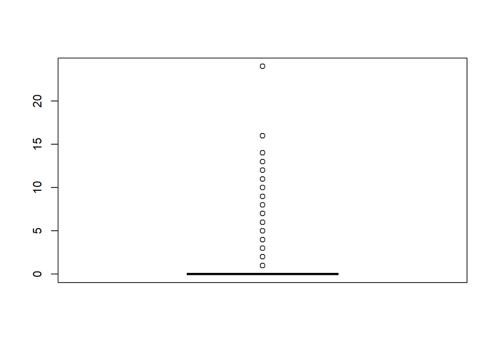

```
##    [1]  1  2  1  1  1  4  1  2  1  2 16  2  1  1  5  1  2  1  3  2  2  1  5  1
##   [25]  1  1  1  1  1  1  4  1  1  1  1  2  2  3  1  1  1  1 14  3  5  1  4  4
##   [49]  4  1  1  2  1  2  1  2  1  3  2  1  1  2  6  1  6  1  2  1  1  3  2  1
##   [73]  1  2  3  1  1  2  1 12  6  2  3  1  3  1  2  5  2  1  1  2  2  1  4  4
##   [97]  3  1  2  4  1  1  1  4  2  1  6  1  1  2  3  3  2  2  3  1  1  1  1  7
##  [121]  2  1  6  2  1  1  1  2  1  5  1  4  4  1  2  3  1  5  2  5  6  3  2  1
##  [145]  2  3  4  2  4  1  3  2  2  1  3  6  1  3  1  1  2  3  1  2  1  3  2  1
##  [169]  1  1  2  2  5  3  3  2  2  1  1  3  1  1  1  4  4  1  2  1  2  2  3  1
##  [193]  3  3  4  1  1  1  1  1  2  1  1  2  1  1  2  2  1  7  1  4  1  1  1  2
##  [217]  1  1  4  1  1  1  3  3  6  1  1  1  1  1  2  2  2  1  2  3  5  1  7  1
##  [241]  4  1  1  1  1  6  3  4  1  9  1  1  1  2  1  6  3  1  3  1  3  3  2  2
##  [265]  2  6  4  1  1  6  1  2  1  1  2  1  3  2  3  1  1  2  2  1  5  2  1  3
##  [289]  1  2  2  2  2  1  3  5  3  3  4  2  1  4  3  1  1  3  1  3  1  2  1  1
##  [313]  5  2  3  1  4 10  2  2  1  1  1  4  2  1  1  1  1  1  4  6  1  6  4  3
##  [337]  3  2  8  3  1  6  1  1  8  2  1  1  1  1  1  1  3  1  3  2  3  1  7  1
```

[output cut: 95 more lines]

```r
boxplot(ecommerce1$Informational)$out
```

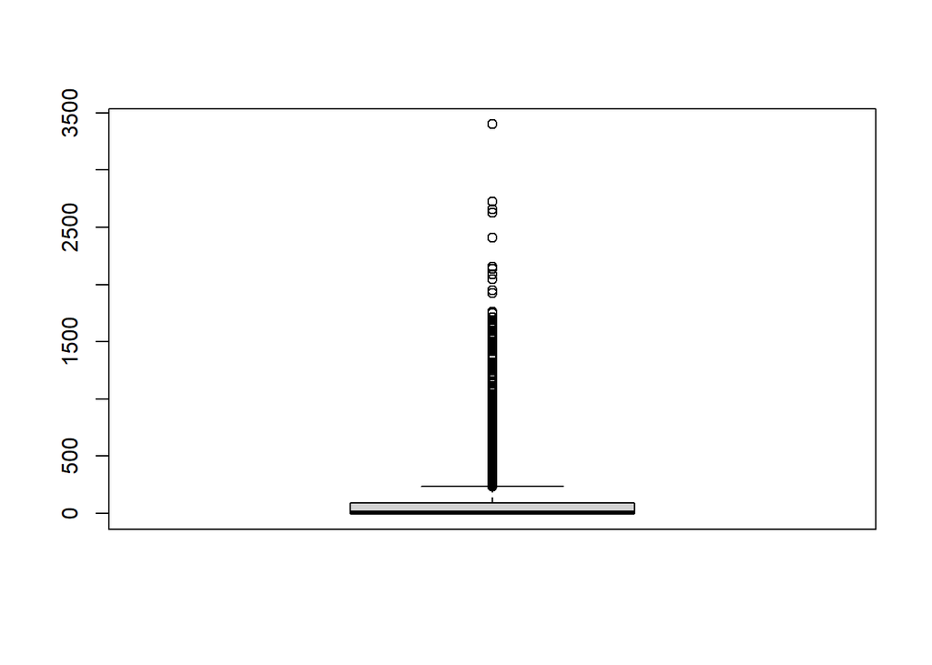

```
##    [1]  279.4167 1005.6667  326.2500  462.0000  293.7782 1226.0000  281.0000
##    [8]  993.0000  666.8333 1388.7500 1249.8095  390.0000  374.0000  615.2500
##   [15]  277.7500  241.1667  618.0000  269.0000  304.0000  312.7500  724.0000
##   [22]  237.5000  279.0000  319.5000  614.1667  315.9667  359.0000 1347.7500
##   [29]  280.9500  416.3929  573.5000  465.8333  311.4091  263.0000  315.1450
##   [36]  523.2143  374.8750  754.1095  504.0000  466.5000  402.1857  306.0000
##   [43]  359.3000  294.7000  262.2500  937.1746  437.3913  281.0000  316.1405
##   [50]  301.7000  421.0000  492.4167  352.5000  274.5000  311.9167  867.9226
##   [57]  241.6667  828.0526  539.5000  285.0119 1521.0000  345.0000  267.1667
##   [64] 1373.5000  272.5000  247.3333  267.5000  387.5000  272.5000  320.5000
##   [71]  308.0000  315.0000 1011.3611  464.0000  243.0000  340.5917  282.0000
##   [78]  512.8333  302.0000  600.4231  710.3333  848.1429  281.6310  487.5000
##   [85]  376.8000  985.5000  606.0000 1640.5909  310.0000 1417.5000  960.0000
##   [92]  613.6667 1499.5714 1223.0000  242.0000  739.2092 1559.7500  249.1667
##   [99]  523.9167  377.8333  298.6667  876.2333  408.2000  382.8333  475.0000
```

[output cut: 152 more lines]

```r
boxplot(ecommerce1$Administrative_Duration)$out
```

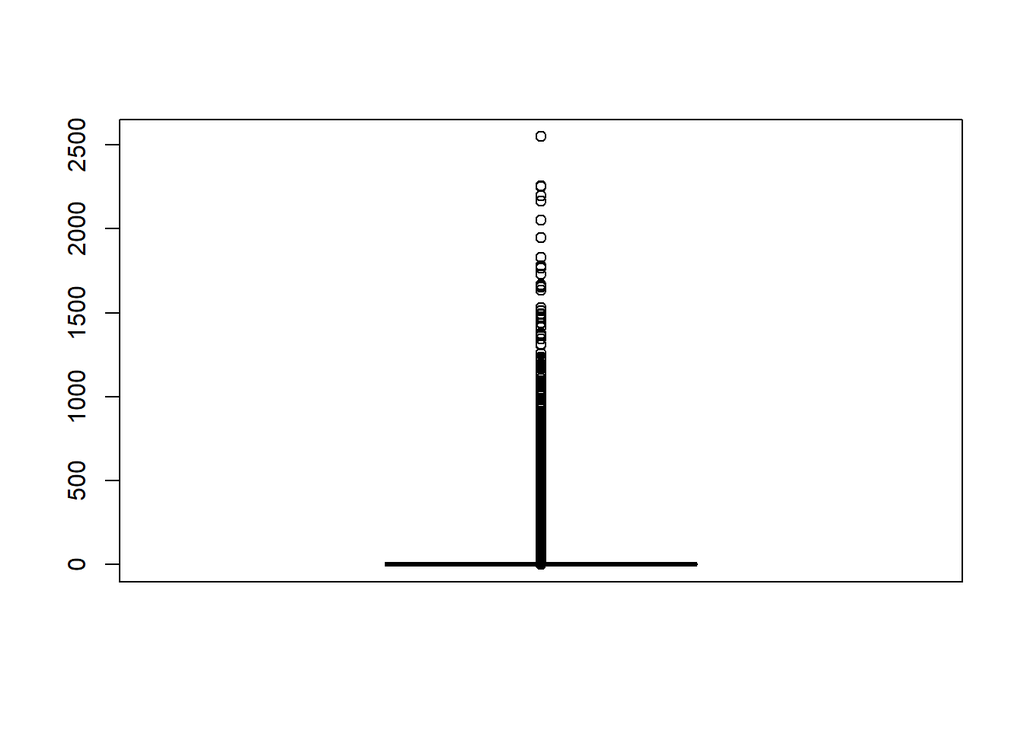

```
##    [1]   -1.000000   -1.000000   -1.000000   -1.000000   -1.000000   -1.000000
##    [7]   -1.000000   -1.000000  120.000000   -1.000000   16.000000   94.000000
##   [13]   93.000000   75.000000   -1.000000   -1.000000   19.000000   22.000000
##   [19]   -1.000000   -1.000000 1210.397619  153.000000   48.500000   51.000000
##   [25]    3.000000  144.000000  125.000000  127.000000  261.000000  306.333333
##   [31]   84.000000  740.000000  303.250000   21.500000 1220.000000  235.000000
##   [37]  100.000000   -1.000000   64.000000   47.000000  205.000000   70.000000
##   [43]   14.333333   24.000000   40.000000  136.000000  116.000000  929.000000
##   [49]   18.000000  155.500000    9.000000 1165.166667   60.000000   -1.000000
##   [55]  528.000000   28.000000  654.333333  246.000000  142.000000   18.500000
##   [61]   39.000000  629.000000  267.500000    4.000000  132.000000   57.000000
##   [67]   14.000000  148.500000  954.000000  762.500000   60.000000  449.333333
##   [73]   71.000000  212.500000   -1.000000 1411.000000   -1.000000  447.000000
##   [79]  125.000000   28.500000   90.000000   -1.000000   18.000000  245.000000
##   [85]   15.000000   -1.000000  125.095238  103.000000  404.000000  147.866667
```

[output cut: 392 more lines]

```r
boxplot(ecommerce1$Informational_Duration)$out
```

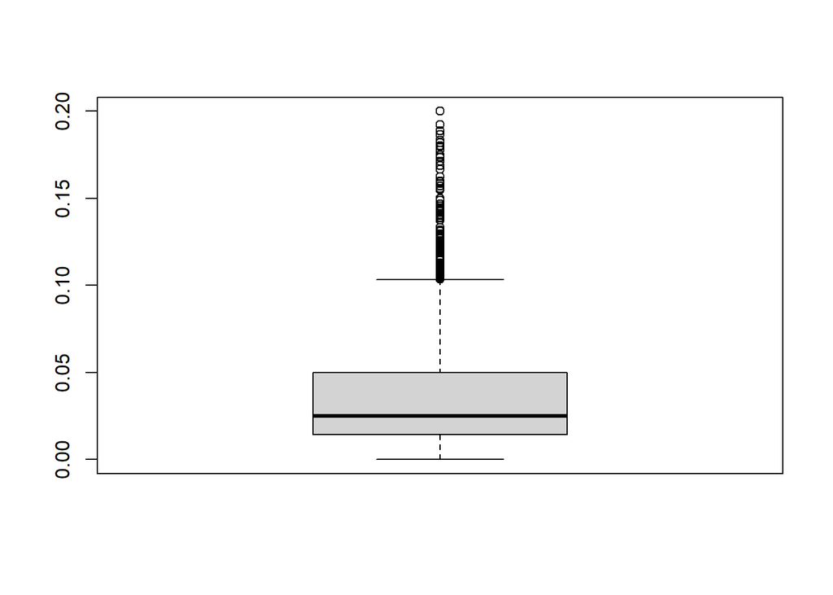

```
##    [1] 0.2000000 0.2000000 0.1400000 0.2000000 0.2000000 0.2000000 0.2000000
##    [8] 0.2000000 0.1333333 0.2000000 0.2000000 0.2000000 0.2000000 0.1208333
##   [15] 0.2000000 0.2000000 0.2000000 0.2000000 0.2000000 0.2000000 0.2000000
##   [22] 0.2000000 0.2000000 0.1500000 0.2000000 0.2000000 0.1111111 0.1195238
##   [29] 0.2000000 0.1666667 0.2000000 0.1500000 0.2000000 0.2000000 0.2000000
##   [36] 0.1500000 0.2000000 0.2000000 0.2000000 0.1666667 0.2000000 0.2000000
##   [43] 0.2000000 0.2000000 0.2000000 0.1200000 0.1500000 0.2000000 0.1200000
##   [50] 0.2000000 0.2000000 0.2000000 0.2000000 0.2000000 0.2000000 0.1100000
##   [57] 0.2000000 0.2000000 0.1250000 0.2000000 0.2000000 0.2000000 0.1333333
##   [64] 0.2000000 0.2000000 0.2000000 0.2000000 0.2000000 0.2000000 0.2000000
##   [71] 0.2000000 0.2000000 0.1166667 0.1333333 0.2000000 0.2000000 0.2000000
##   [78] 0.2000000 0.2000000 0.2000000 0.2000000 0.1333333 0.2000000 0.2000000
##   [85] 0.2000000 0.2000000 0.1666667 0.1250000 0.2000000 0.2000000 0.2000000
##   [92] 0.2000000 0.1285714 0.2000000 0.2000000 0.2000000 0.2000000 0.2000000
##   [99] 0.2000000 0.1200000 0.2000000 0.2000000 0.2000000 0.1500000 0.2000000
```

[output cut: 142 more lines]

```r
boxplot(ecommerce1$ExitRates)$out
```

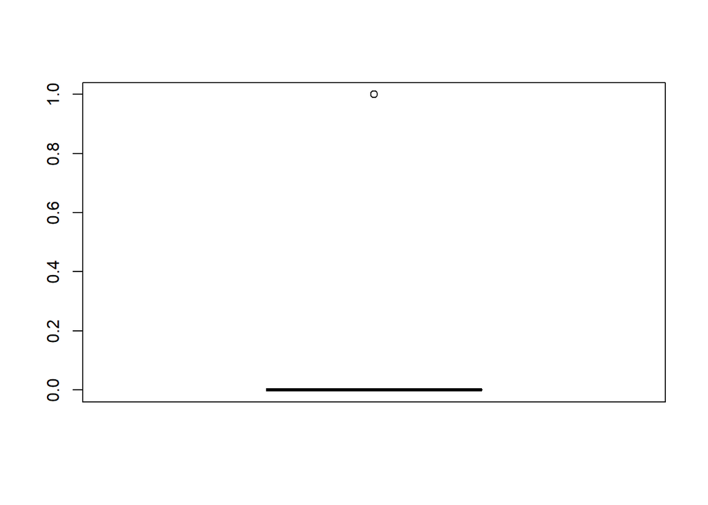

[output not shown]

[output cut: 37 more lines]

```r
boxplot(ecommerce1$Revenue)$out
```

### EXPLORATORY DATA ANALYSIS.

#### UNIVARIATE ANALYSIS.

1. Administrative.
2. Daily time spent on Site

```r
mean(ecommerce1$Administrative, trim = 0, na.rm=FALSE)
```

```
## [1] 2.316707
```

```r
median(ecommerce1$Administrative,na.rm=FALSE)
```

```
## [1] 1
```

```r
range(ecommerce1$Administrative,na.rm=FALSE, finite=FALSE)
```

```
## [1]  0 27
```

```r
quantile(ecommerce1$Administrative, probs=seq(0, 1,0.25), na.rm=FALSE, names=TRUE, type=7)
```

```
##   0%  25%  50%  75% 100%
##    0    0    1    4   27
```

```r
var(ecommerce1$Administrative)
```

```
## [1] 11.04179
```

```r
sd(ecommerce1$Administrative,na.rm=FALSE)
```

```
## [1] 3.322919
```

mode

```r
getmode <- function(v){
   uniqv <- unique(v)
   uniqv[which.max(tabulate(match(v, uniqv)))]
}
```

```r
adm_mode <- getmode(ecommerce1$Administrative)
adm_mode
```

```
## [1] 0
```

Visualizing Administrative colmn.

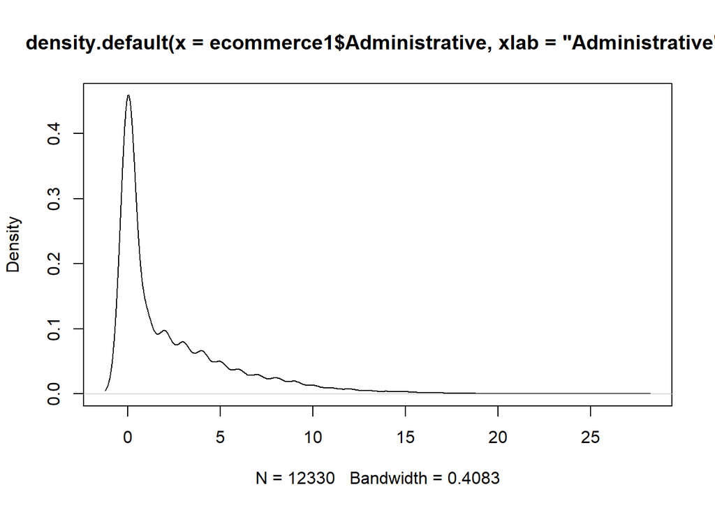

```r
plot_adm <- density(ecommerce1$Administrative, xlab="Administrative")
plot(plot_adm)
```

Most users who visited the administrative pages were between 0 and 3 users.

2. Administrative Duration.

```r
mean(ecommerce1$Administrative_Duration , trim = 0, na.rm=FALSE)
```

```
## [1] 80.84786
```

```r
median(ecommerce1$Administrative_Duration ,na.rm=FALSE)
```

```
## [1] 7.6125
```

```r
range(ecommerce1$Administrative_Duration ,na.rm=FALSE, finite=FALSE)
```

```
## [1]   -1.00 3398.75
```

```r
quantile(ecommerce1$Administrative_Duration , probs=seq(0, 1,0.25), na.rm=FALSE, names=TRUE, type=7)
```

```
##        0%       25%       50%       75%      100%
##   -1.0000    0.0000    7.6125   93.3750 3398.7500
```

```r
var(ecommerce1$Administrative_Duration )
```

```
## [1] 31255.66
```

```r
sd(ecommerce1$Administrative_Duration ,na.rm=FALSE)
```

```
## [1] 176.7927
```

mode

```r
getmode <- function(v){
   uniqv <- unique(v)
   uniqv[which.max(tabulate(match(v, uniqv)))]
}
```

```r
adm_dur_mode <- getmode(ecommerce1$Administrative_Duration)
adm_dur_mode
```

```
## [1] 0
```

Visualizing Administratve Duration.

```r
d <- density(ecommerce1$Administrative_Duration, xlab="Administrative Duration")
```

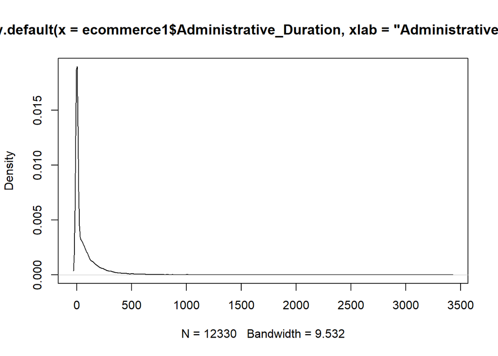

```r
plot(d)
```

Highest duration spent on the administrative pages lies between 0 to 200 minutes.

#### c. Informational Duration

```r
mean(ecommerce1$Informational_Duration , trim = 0, na.rm=FALSE)
```

```
## [1] 34.48347
```

```r
median(ecommerce1$Informational_Duration ,na.rm=FALSE)
```

```
## [1] 0
```

```r
range(ecommerce1$Informational_Duration ,na.rm=FALSE, finite=FALSE)
```

```
## [1]   -1.000 2549.375
```

```r
quantile(ecommerce1$Informational_Duration , probs=seq(0, 1,0.25), na.rm=FALSE, names=TRUE, type=7)
```

```
##       0%      25%      50%      75%     100%
##   -1.000    0.000    0.000    0.000 2549.375
```

```r
var(ecommerce1$Informational_Duration )
```

```
## [1] 19812.57
```

```r
sd(ecommerce1$Informational_Duration ,na.rm=FALSE)
```

```
## [1] 140.7571
```

mode

```r
getmode <- function(v){
   uniqv <- unique(v)
   uniqv[which.max(tabulate(match(v, uniqv)))]
}
```

```r
info_dur_mode <- getmode(ecommerce1$Informational_Duration)
info_dur_mode
```

```
## [1] 0
```

Visualizing Information Duration.

```r
par(mfrow=c(1,2))
info <- density(ecommerce1$Informational , xlab="Informational  Duration")
```

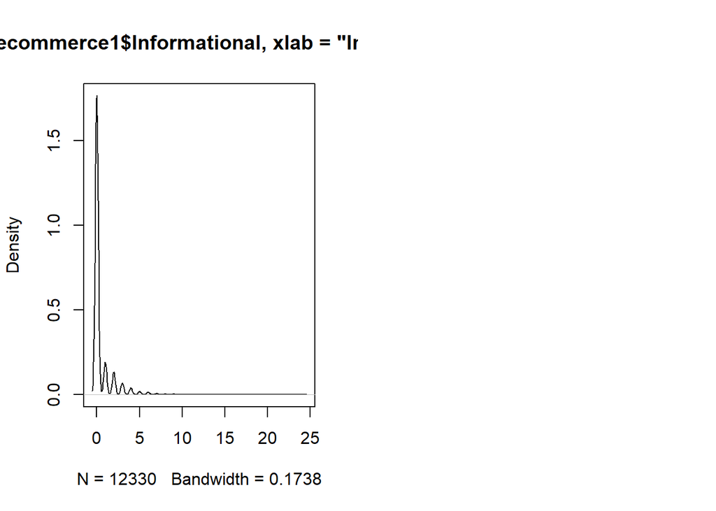

```r
plot(info)

par(mfrow=c(2,2))
```

```r
info_duration <- density(ecommerce1$Informational_Duration, xlab="Information  Duration")
```

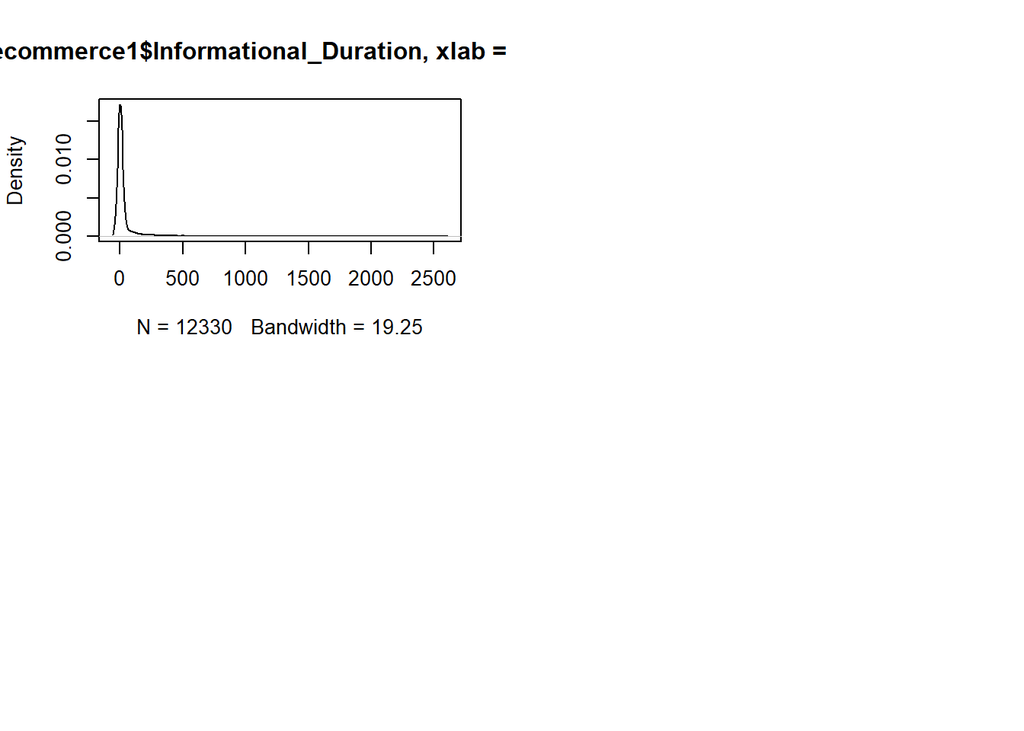

```r
plot(info_duration)
```

#### d. Product Related_Duration

```r
mean(ecommerce1$ProductRelated_Duration , trim = 0, na.rm=FALSE)
```

```
## [1] 1195.765
```

```r
median(ecommerce1$ProductRelated_Duration ,na.rm=FALSE)
```

```
## [1] 599.4167
```

```r
range(ecommerce1$ProductRelated_Duration ,na.rm=FALSE, finite=FALSE)
```

```
## [1]    -1.00 63973.52
```

```r
quantile(ecommerce1$ProductRelated_Duration , probs=seq(0, 1,0.25), na.rm=FALSE, names=TRUE, type=7)
```

```
##         0%        25%        50%        75%       100%
##    -1.0000   185.0000   599.4167  1465.2707 63973.5222
```

```r
var(ecommerce1$ProductRelated_Duration )
```

```
## [1] 3665825
```

```r
sd(ecommerce1$ProductRelated_Duration ,na.rm=FALSE)
```

```
## [1] 1914.634
```

mode

```r
getmode <- function(v){
   uniqv <- unique(v)
   uniqv[which.max(tabulate(match(v, uniqv)))]
}
```

```r
productrelated_mode <- getmode(ecommerce1$ProductRelated)
productrelated_mode
```

```
## [1] 1
```

```r
par(mfrow=c(1,2))
product <- density(ecommerce1$ProductRelated, xlab="Product Related")
```

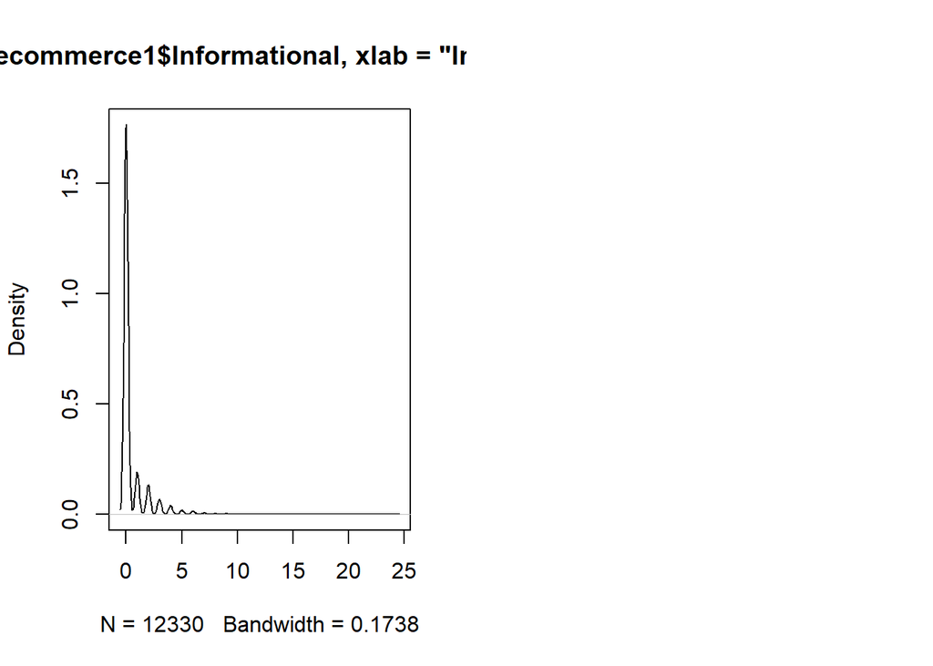

```r
plot(info)

par(mfrow=c(2,2))
```

```r
product_related <- density(ecommerce1$ProductRelated_Duration, xlab="Product Related Duration")
```

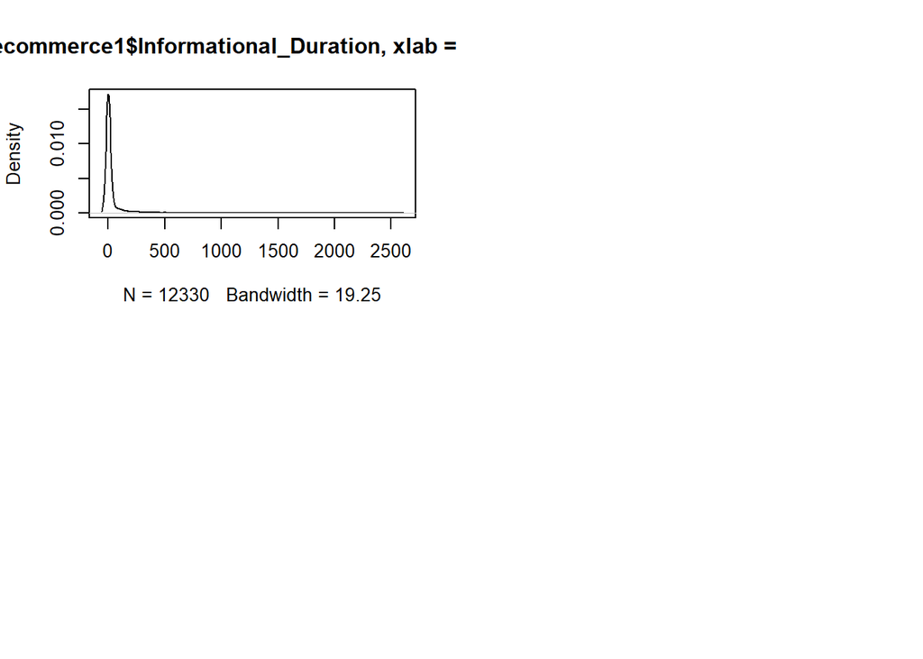

```r
plot(info_duration)
```

5. Bounce Rates

```r
mean(ecommerce1$BounceRates , trim = 0, na.rm=FALSE)
```

```
## [1] 0.02214818
```

```r
median(ecommerce1$BounceRates ,na.rm=FALSE)
```

```
## [1] 0.003125
```

```r
range(ecommerce1$BounceRates ,na.rm=FALSE, finite=FALSE)
```

```
## [1] 0.0 0.2
```

```r
quantile(ecommerce1$BounceRates , probs=seq(0, 1,0.25), na.rm=FALSE, names=TRUE, type=7)
```

```
##         0%        25%        50%        75%       100%
## 0.00000000 0.00000000 0.00312500 0.01676421 0.20000000
```

```r
var(ecommerce1$BounceRates )
```

```
## [1] 0.002343323
```

```r
sd(ecommerce1$BounceRates ,na.rm=FALSE)
```

```
## [1] 0.04840788
```

mode

```r
getmode <- function(v){
   uniqv <- unique(v)
   uniqv[which.max(tabulate(match(v, uniqv)))]
}
```

```r
bouncerate_mode <- getmode(ecommerce1$BounceRates)
bouncerate_mode
```

```
## [1] 0
```

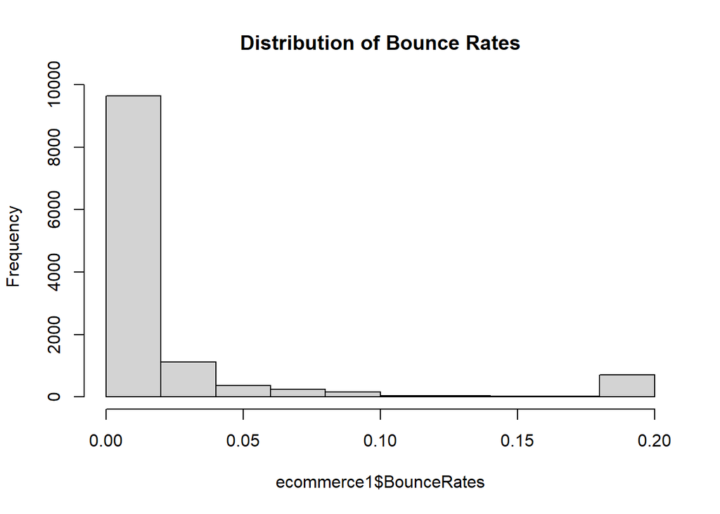

```r
hist(ecommerce1$BounceRates, breaks=12, xlabs='Bounce Rates', main='Distribution of Bounce Rates')
```

Most bounce rates lied at 0.00 to 0.02

##### e. Exit Rates

```r
mean(ecommerce1$ExitRates , trim = 0, na.rm=FALSE)
```

```
## [1] 0.04300907
```

```r
median(ecommerce1$ExitRates ,na.rm=FALSE)
```

```
## [1] 0.02513522
```

```r
range(ecommerce1$ExitRates ,na.rm=FALSE, finite=FALSE)
```

```
## [1] 0.0 0.2
```

```r
quantile(ecommerce1$ExitRates , probs=seq(0, 1,0.25), na.rm=FALSE, names=TRUE, type=7)
```

```
##         0%        25%        50%        75%       100%
## 0.00000000 0.01428571 0.02513522 0.05000000 0.20000000
```

```r
var(ecommerce1$ExitRates )
```

```
## [1] 0.002354163
```

```r
sd(ecommerce1$ExitRates ,na.rm=FALSE)
```

```
## [1] 0.04851972
```

mode

```r
getmode <- function(v){
   uniqv <- unique(v)
   uniqv[which.max(tabulate(match(v, uniqv)))]
}
```

```r
exitrate_mode <- getmode(ecommerce1$ExitRates)
exitrate_mode
```

```
## [1] 0.2
```

Visualizing Exit Rates.

```r
d <- density(ecommerce1$ExitRates, xlab="Exit Rates")
```

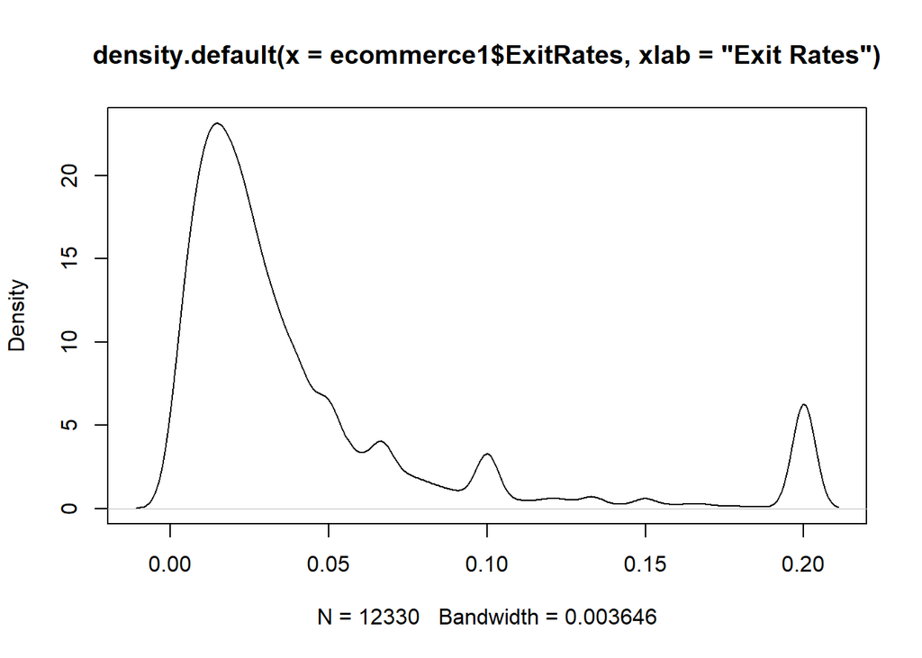

```r
plot(d)
```

##### f. Page Value

```r
mean(ecommerce1$PageValues , trim = 0, na.rm=FALSE)
```

```
## [1] 5.889258
```

```r
median(ecommerce1$PageValues ,na.rm=FALSE)
```

```
## [1] 0
```

```r
range(ecommerce1$PageValues ,na.rm=FALSE, finite=FALSE)
```

```
## [1]   0.0000 361.7637
```

```r
quantile(ecommerce1$PageValues , probs=seq(0, 1,0.25), na.rm=FALSE, names=TRUE, type=7)
```

```
##       0%      25%      50%      75%     100%
##   0.0000   0.0000   0.0000   0.0000 361.7637
```

```r
var(ecommerce1$PageValues )
```

```
## [1] 344.7868
```

```r
sd(ecommerce1$PageValues ,na.rm=FALSE)
```

```
## [1] 18.56844
```

mode

```r
page_valuemode <- getmode(ecommerce1$PageValues)
page_valuemode
```

```
## [1] 0
```

Visualizing Page Value.

```r
pagevalue <- density(ecommerce1$PageValues, xlab="Exit Rates")
```

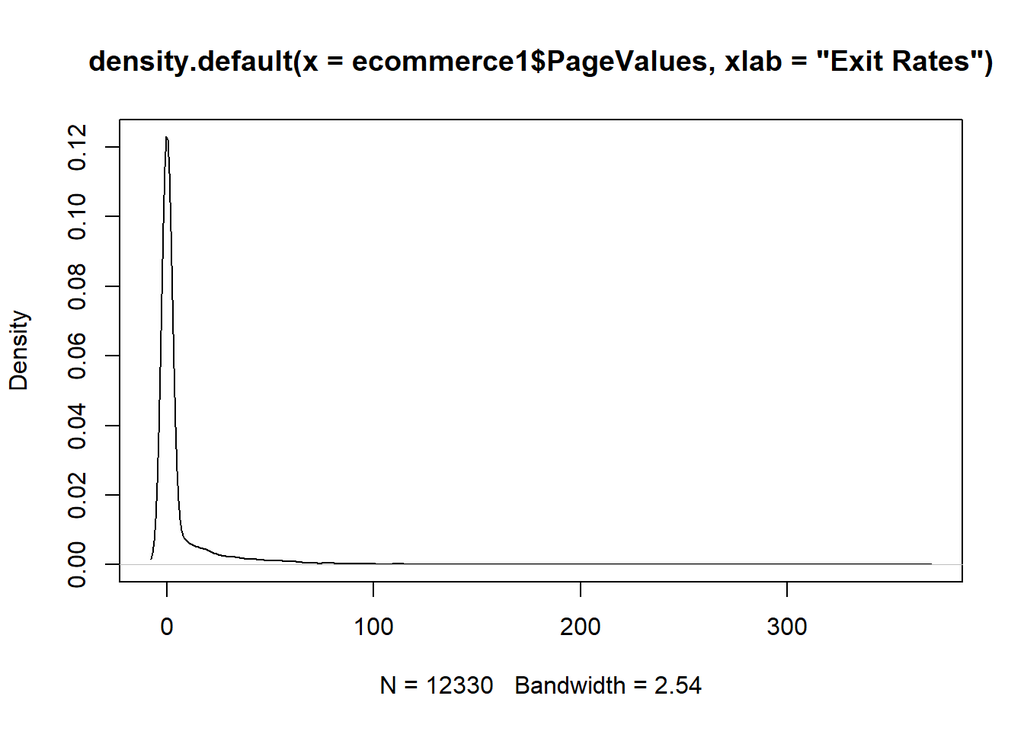

```r
plot(pagevalue)
```

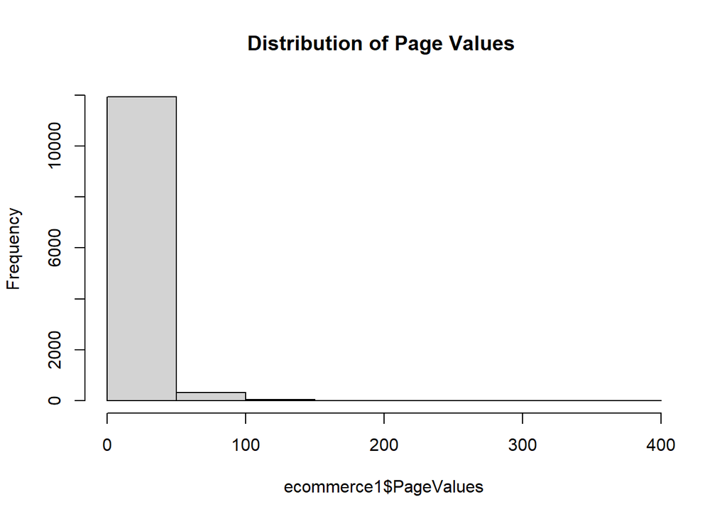

```r
hist(ecommerce1$PageValues, breaks=12, xlabs='Page Values ', main='Distribution of Page Values ')
```

```r
str(ecommerce1)
```

```
## 'data.frame':    12330 obs. of  18 variables:
##  $ Administrative         : int  0 0 0 0 0 0 0 1 0 0 ...
##  $ Administrative_Duration: num  0 0 -1 0 0 0 -1 -1 0 0 ...
##  $ Informational          : int  0 0 0 0 0 0 0 0 0 0 ...
##  $ Informational_Duration : num  0 0 -1 0 0 0 -1 -1 0 0 ...
##  $ ProductRelated         : int  1 2 1 2 10 19 1 1 2 3 ...
##  $ ProductRelated_Duration: num  0 64 -1 2.67 627.5 ...
##  $ BounceRates            : num  0.2 0 0.2 0.05 0.02 ...
##  $ ExitRates              : num  0.2 0.1 0.2 0.14 0.05 ...
##  $ PageValues             : num  0 0 0 0 0 0 0 0 0 0 ...
##  $ SpecialDay             : num  0 0 0 0 0 0 0.4 0 0.8 0.4 ...
##  $ Month                  : chr  "Feb" "Feb" "Feb" "Feb" ...
##  $ OperatingSystems       : int  1 2 4 3 3 2 2 1 2 2 ...
##  $ Browser                : int  1 2 1 2 3 2 4 2 2 4 ...
##  $ Region                 : int  1 1 9 2 1 1 3 1 2 1 ...
##  $ TrafficType            : int  1 2 3 4 4 3 3 5 3 2 ...
##  $ VisitorType            : chr  "Returning_Visitor" "Returning_Visitor" "Returning_Visitor" "Returning_Visitor" ...
##  $ Weekend                : logi  FALSE FALSE FALSE FALSE TRUE FALSE ...
##  $ Revenue                : logi  FALSE FALSE FALSE FALSE FALSE FALSE ...
```

### BIVARIATE ANALYSIS.

#### Covariance.

```r
head(ecommerce1)
```

```
##   Administrative Administrative_Duration Informational Informational_Duration
## 1              0                       0             0                      0
## 2              0                       0             0                      0
## 3              0                      -1             0                     -1
## 4              0                       0             0                      0
## 5              0                       0             0                      0
## 6              0                       0             0                      0
##   ProductRelated ProductRelated_Duration BounceRates ExitRates PageValues
## 1              1                0.000000  0.20000000 0.2000000          0
## 2              2               64.000000  0.00000000 0.1000000          0
## 3              1               -1.000000  0.20000000 0.2000000          0
## 4              2                2.666667  0.05000000 0.1400000          0
## 5             10              627.500000  0.02000000 0.0500000          0
## 6             19              154.216667  0.01578947 0.0245614          0
##   SpecialDay Month OperatingSystems Browser Region TrafficType
## 1          0   Feb                1       1      1           1
## 2          0   Feb                2       2      1           2
## 3          0   Feb                4       1      9           3
## 4          0   Feb                3       2      2           4
## 5          0   Feb                3       3      1           4
## 6          0   Feb                2       2      1           3
##         VisitorType Weekend Revenue
## 1 Returning_Visitor   FALSE   FALSE
## 2 Returning_Visitor   FALSE   FALSE
## 3 Returning_Visitor   FALSE   FALSE
## 4 Returning_Visitor   FALSE   FALSE
## 5 Returning_Visitor    TRUE   FALSE
## 6 Returning_Visitor   FALSE   FALSE
```

```r
ecommerce_cov <- ecommerce1[,c(1,2,3,4,5,6,7,8,9,10,12,13,14,15)]

cov(ecommerce_cov)
```

```
##                         Administrative Administrative_Duration Informational
## Administrative             11.04179238              353.436708   1.591445492
## Administrative_Duration   353.43670774            31255.655263  68.000055544
## Informational               1.59144549               68.000056   1.613458382
## Informational_Duration    119.59445332             5921.162252 110.669128760
## ProductRelated             63.66411671             2270.103214  21.166012712
## ProductRelated_Duration  2375.66441462           120153.940248 942.661640848
## BounceRates                -0.03593567               -1.233409  -0.007138408
## ExitRates                  -0.05095825               -1.763642  -0.010081957
## PageValues                  6.09663522              221.753380   1.146014306
## SpecialDay                 -0.06271993               -2.579609  -0.012192851
## OperatingSystems           -0.01835066               -1.160834  -0.010723035
## Browser                    -0.14335809               -4.684524  -0.083293571
## Region                     -0.04635064               -2.418357  -0.089810913
## TrafficType                -0.45232661              -10.294978  -0.176835183
##                         Informational_Duration ProductRelated
## Administrative                     119.5944533     63.6641167
## Administrative_Duration           5921.1622516   2270.1032141
## Informational                      110.6691288     21.1660127
## Informational_Duration           19812.5660682   1756.0291125
## ProductRelated                    1756.0291125   1984.3966518
## ProductRelated_Duration          93646.3539582  73421.8803478
## BounceRates                         -0.5047193     -0.4404684
## ExitRates                           -0.7187460     -0.6313011
## PageValues                          80.5895165     46.2132458
## SpecialDay                          -0.8568758     -0.2147368
## OperatingSystems                    -1.2270938      0.1689829
## Browser                             -4.6642658     -1.0232714
## Region                              -9.1869225     -4.1062784
## TrafficType                        -14.0200322     -7.8129961
##                         ProductRelated_Duration   BounceRates     ExitRates
## Administrative                     2.375664e+03 -3.593567e-02 -5.095825e-02
## Administrative_Duration            1.201539e+05 -1.233409e+00 -1.763642e+00
## Informational                      9.426616e+02 -7.138408e-03 -1.008196e-02
## Informational_Duration             9.364635e+04 -5.047193e-01 -7.187460e-01
## ProductRelated                     7.342188e+04 -4.404684e-01 -6.313011e-01
## ProductRelated_Duration            3.665825e+06 -1.708500e+01 -2.337915e+01
## BounceRates                       -1.708500e+01  2.343323e-03  2.145103e-03
## ExitRates                         -2.337915e+01  2.145103e-03  2.354163e-03
## PageValues                         1.871005e+03 -1.072351e-01 -1.570852e-01
```

[output cut: 20 more lines]

```
##                               Browser        Region   TrafficType
## Administrative          -1.433581e-01 -4.635064e-02   -0.45232661
## Administrative_Duration -4.684524e+00 -2.418357e+00  -10.29497787
## Informational           -8.329357e-02 -8.981091e-02   -0.17683518
## Informational_Duration  -4.664266e+00 -9.186923e+00  -14.02003222
## ProductRelated          -1.023271e+00 -4.106278e+00   -7.81299608
## ProductRelated_Duration -2.465440e+01 -1.524942e+02 -282.68740332
## BounceRates             -1.318676e-03 -7.822936e-04    0.01532647
## ExitRates               -3.624718e-04 -1.039513e-03    0.01534967
## PageValues               1.453796e+00  5.045921e-01    0.93663247
## SpecialDay               1.195158e-03 -7.690292e-03    0.04187649
## OperatingSystems         3.490145e-01  1.680331e-01    0.69386020
## Browser                  2.949039e+00  4.016673e-01    0.77375385
## Region                   4.016673e-01  5.767640e+00    0.45936909
## TrafficType              7.737538e-01  4.593691e-01   16.20198677
```

#### Correlation.

```r
ecommerce1.cor<-cor(ecommerce_cov, method=c('spearman'))
```

visualizing

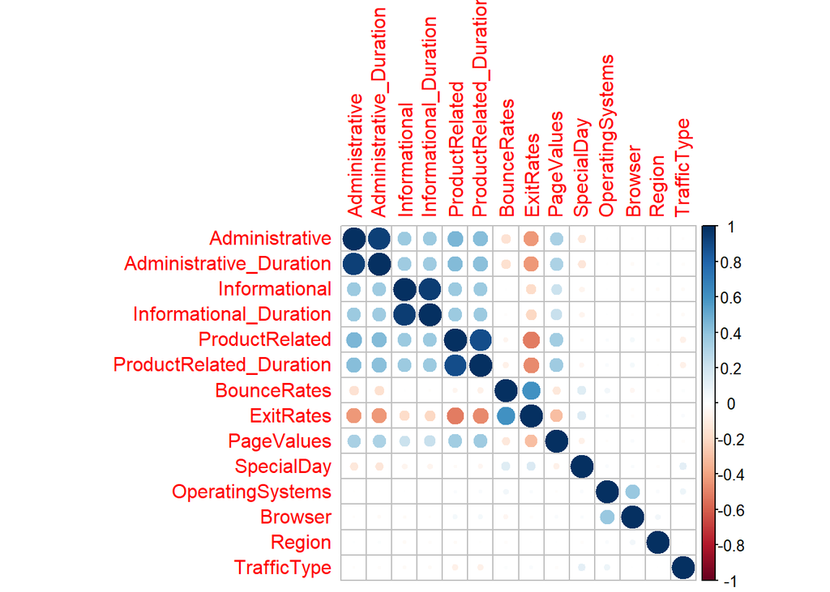

```r
install.packages('corrplot')
library(corrplot)
corrplot(ecommerce1.cor)
```

Administrative and administrative duration are highly corelated. Information and information duration are correlated. Also product related duraion and product related.

1. Administrative Duration and Administrative

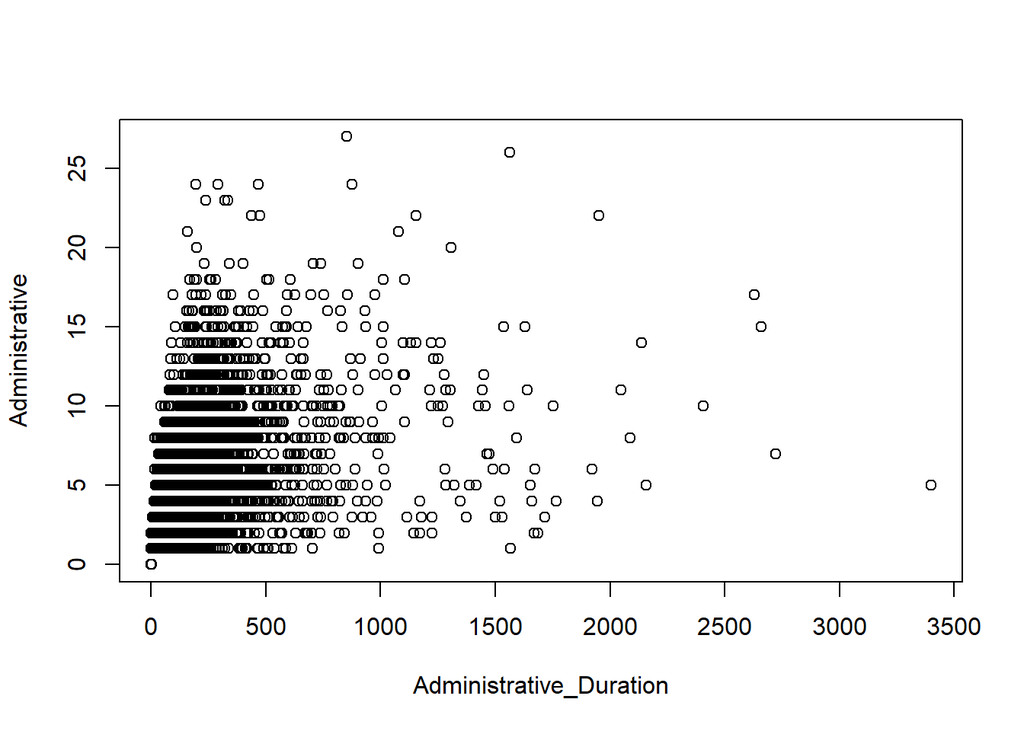

```r
plot(ecommerce1$Administrative_Duration, ecommerce1$Administrative, xlab="Administrative_Duration", ylab="Administrative")
```

An increase in administrative page visits correspondingly increased with the visits of administrative duration pages.

2. Informational Duration and Informational Page Visits.

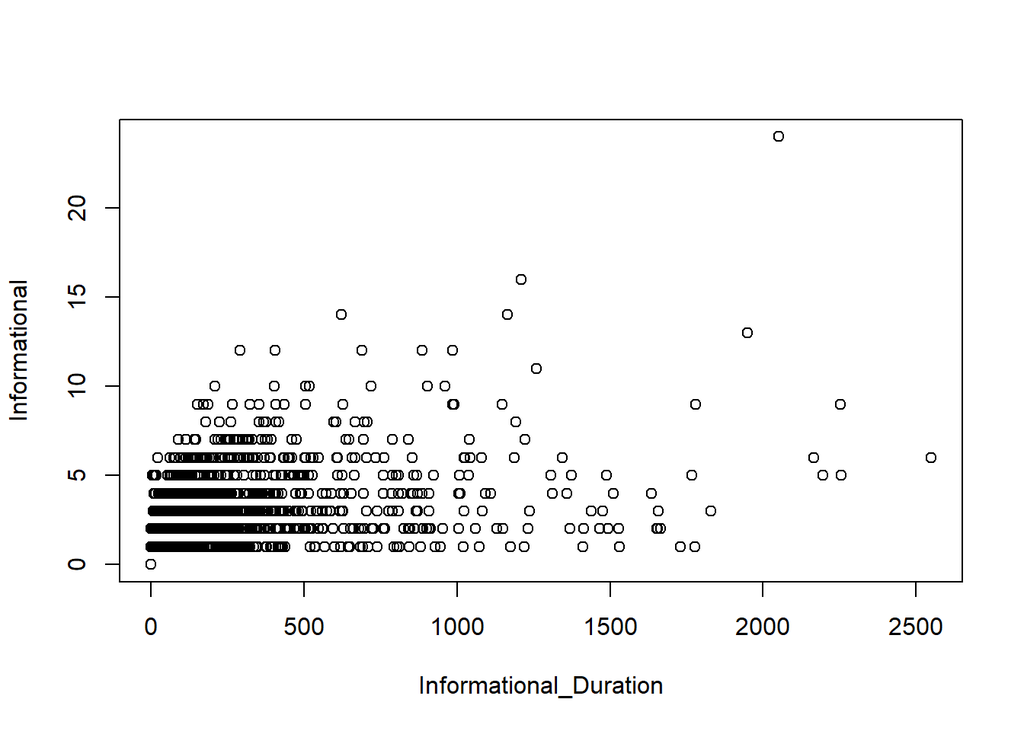

```r
plot(ecommerce1$Informational_Duration, ecommerce1$Informational, xlab="Informational_Duration", ylab="Informational")
```

As visits to Informational pages increase, Informational Duration page visits equally increases.

3.Product Related Duration and Product Related page visists.

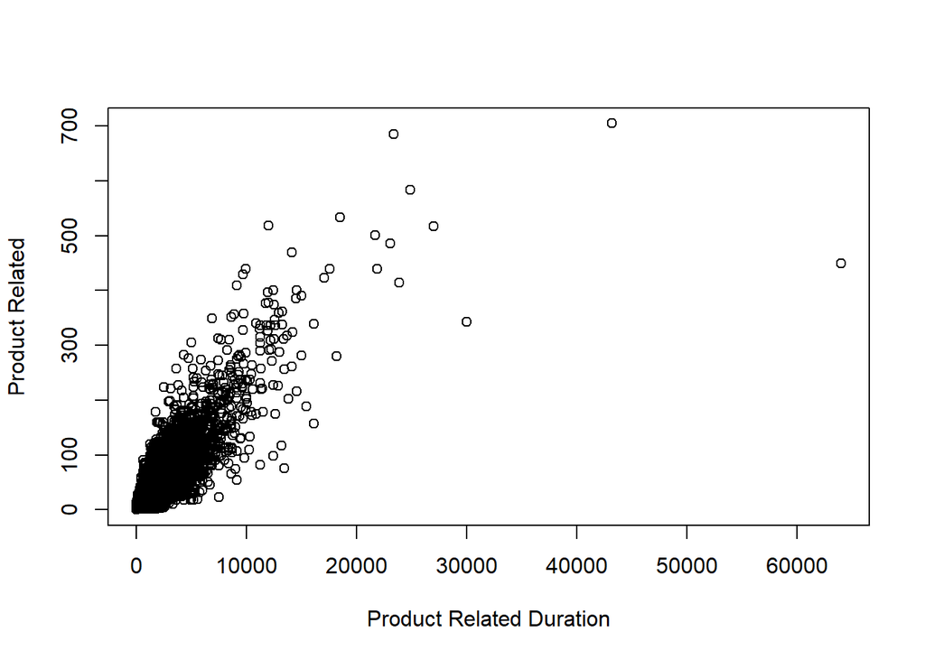

```r
plot(ecommerce1$ProductRelated_Duration, ecommerce1$ProductRelated, xlab="Product Related Duration", ylab="Product Related")
```

A similar increase was observed when both in Product related duration and product related page visits.

4. Administrative duration and Informational Duration

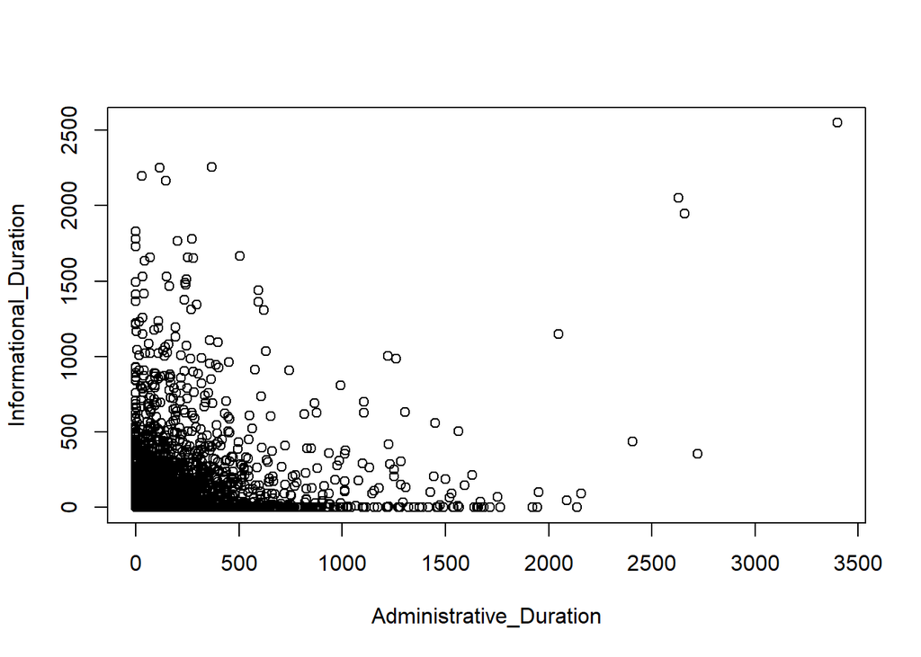

```r
plot(ecommerce1$Administrative_Duration, ecommerce1$Informational_Duration, xlab="Administrative_Duration", ylab="Informational_Duration")
```

5. Administrative duration and product related duration.

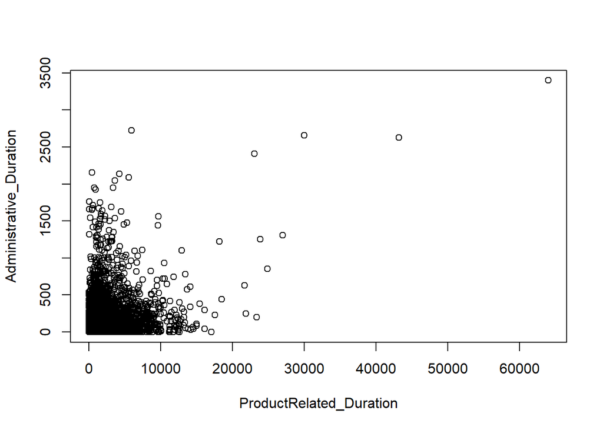

```r
plot(ecommerce1$ProductRelated_Duration,ecommerce1$Administrative_Duration,  xlab="ProductRelated_Duration", ylab="Administrative_Duration")
```

6. Exit rates and Bounce Rate.

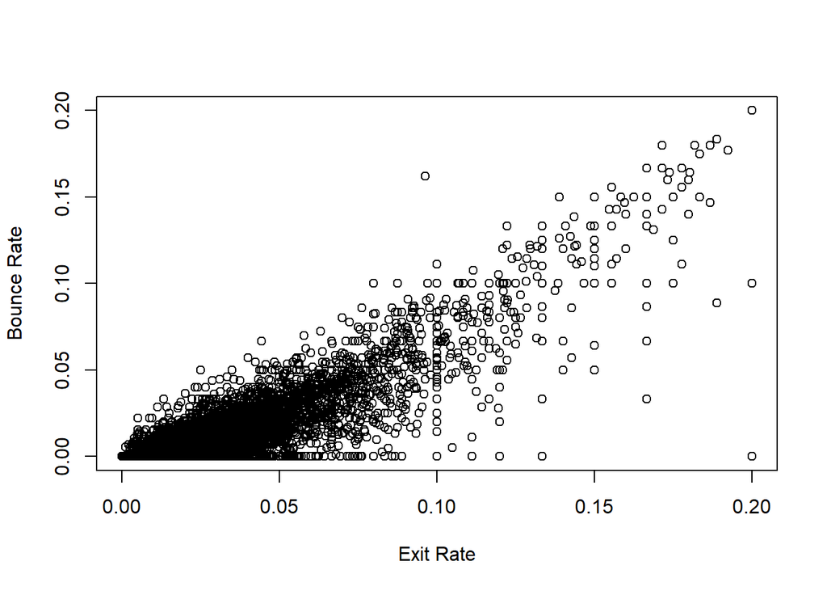

```r
plot(ecommerce1$ExitRates,ecommerce1$BounceRates, xlab="Exit Rate", ylab="Bounce Rate")
```

### Implementing Solutions.

#### Noramilizing numerical columns

```r
#class variable
ecommerce.class <- ecommerce1[, 18]
head(ecommerce.class)
```

```
## [1] FALSE FALSE FALSE FALSE FALSE FALSE
```

```r
norm <- function(x){
  return((x-min(x))/(max(x)-min(x)))
}

ecommerce_new <- as.data.frame(lapply(ecommerce1[,c(1,2,3,4,5,6,7,8,9,10,12,13,14,15)], norm))
ecommerce.class <- ecommerce1[, 18]
head(ecommerce_new)
```

```
##   Administrative Administrative_Duration Informational Informational_Duration
## 1              0            0.0002941393             0           0.0003920992
## 2              0            0.0002941393             0           0.0003920992
## 3              0            0.0000000000             0           0.0000000000
## 4              0            0.0002941393             0           0.0003920992
## 5              0            0.0002941393             0           0.0003920992
## 6              0            0.0002941393             0           0.0003920992
##   ProductRelated ProductRelated_Duration BounceRates ExitRates PageValues
## 1    0.001418440            1.563122e-05  1.00000000  1.000000          0
## 2    0.002836879            1.016029e-03  0.00000000  0.500000          0
## 3    0.001418440            0.000000e+00  1.00000000  1.000000          0
## 4    0.002836879            5.731448e-05  0.25000000  0.700000          0
## 5    0.014184397            9.824223e-03  0.10000000  0.250000          0
## 6    0.026950355            2.426226e-03  0.07894737  0.122807          0
##   SpecialDay OperatingSystems    Browser Region TrafficType
## 1          0        0.0000000 0.00000000  0.000  0.00000000
## 2          0        0.1428571 0.08333333  0.000  0.05263158
## 3          0        0.4285714 0.00000000  1.000  0.10526316
## 4          0        0.2857143 0.08333333  0.125  0.15789474
## 5          0        0.2857143 0.16666667  0.000  0.15789474
## 6          0        0.1428571 0.08333333  0.000  0.10526316
```

Finding number of clusters

```r
#using elbow method
pkgs <- c("factoextra",  "NbClust")
install.packages(pkgs)
library(factoextra)
library(NbClust)

#standardizing data
std.ecommerce_new <- scale(ecommerce_new)
head(std.ecommerce_new)
```

```
##      Administrative Administrative_Duration Informational
## [1,]     -0.6971903              -0.4573032    -0.3965697
## [2,]     -0.6971903              -0.4573032    -0.3965697
## [3,]     -0.6971903              -0.4629595    -0.3965697
## [4,]     -0.6971903              -0.4573032    -0.3965697
## [5,]     -0.6971903              -0.4573032    -0.3965697
## [6,]     -0.6971903              -0.4573032    -0.3965697
##      Informational_Duration ProductRelated ProductRelated_Duration BounceRates
## [1,]             -0.2449856     -0.6908888              -0.6245397  3.67402627
## [2,]             -0.2449856     -0.6684404              -0.5911129 -0.45753261
## [3,]             -0.2520900     -0.6908888              -0.6250620  3.67402627
## [4,]             -0.2449856     -0.6684404              -0.6231469  0.57535711
## [5,]             -0.2449856     -0.4888530              -0.2968009 -0.04437672
## [6,]             -0.2449856     -0.2868172              -0.5439934 -0.13135690
##       ExitRates PageValues SpecialDay OperatingSystems    Browser     Region
## [1,]  3.2356111  -0.317165 -0.3088088       -1.2333763 -0.7902608 -0.8941422
## [2,]  1.1745933  -0.317165 -0.3088088       -0.1360728 -0.2079435 -0.8941422
## [3,]  3.2356111  -0.317165 -0.3088088        2.0585344 -0.7902608  2.4369825
## [4,]  1.9990004  -0.317165 -0.3088088        0.9612308 -0.2079435 -0.4777516
## [5,]  0.1440844  -0.317165 -0.3088088        0.9612308  0.3743739 -0.8941422
## [6,] -0.3802096  -0.317165 -0.3088088       -0.1360728 -0.2079435 -0.8941422
##      TrafficType
## [1,] -0.76259811
## [2,] -0.51416134
## [3,] -0.26572458
## [4,] -0.01728781
## [5,] -0.01728781
## [6,] -0.26572458
```

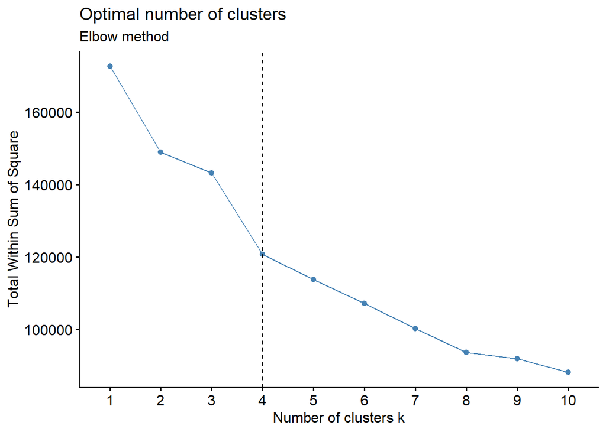

```r
#Finding optimal number of clusters
fviz_nbclust(std.ecommerce_new, kmeans, method = "wss") +
    geom_vline(xintercept = 4, linetype = 2)+
  labs(subtitle = "Elbow method")
```

```r
results <- kmeans(std.ecommerce_new, 3)
results
```

```
## K-means clustering with 3 clusters of sizes 9850, 1392, 1088
##
## Cluster means:
##   Administrative Administrative_Duration Informational Informational_Duration
## 1      0.1092683               0.0751861    0.07427087             0.04831089
## 2     -0.2412400              -0.1813425   -0.22520380            -0.15071501
## 3     -0.6805944              -0.4486713   -0.38426872            -0.24454681
##   ProductRelated ProductRelated_Duration BounceRates  ExitRates  PageValues
## 1      0.0964126              0.08768909  -0.2789249 -0.2772100  0.02258207
## 2     -0.1826063             -0.15879256  -0.2967875 -0.1989518  0.08810500
## 3     -0.6392244             -0.59071536   2.9049071  2.7642086 -0.31716498
##    SpecialDay OperatingSystems     Browser      Region TrafficType
## 1 -0.03667571      -0.01843291 -0.29703509 -0.01659377 -0.03385867
## 2  0.04006258       0.06809507  2.15270076  0.14922730  0.03090035
## 3  0.28078004       0.07975717 -0.06504025 -0.04069460  0.26699874
```

[output cut: 354 more lines]

```r
#records in each cluster
results$size
```

```
## [1] 9850 1392 1088
```

```r
#value of cluster center
results$centers
```

```
##   Administrative Administrative_Duration Informational Informational_Duration
## 1      0.1092683               0.0751861    0.07427087             0.04831089
## 2     -0.2412400              -0.1813425   -0.22520380            -0.15071501
## 3     -0.6805944              -0.4486713   -0.38426872            -0.24454681
##   ProductRelated ProductRelated_Duration BounceRates  ExitRates  PageValues
## 1      0.0964126              0.08768909  -0.2789249 -0.2772100  0.02258207
## 2     -0.1826063             -0.15879256  -0.2967875 -0.1989518  0.08810500
## 3     -0.6392244             -0.59071536   2.9049071  2.7642086 -0.31716498
##    SpecialDay OperatingSystems     Browser      Region TrafficType
## 1 -0.03667571      -0.01843291 -0.29703509 -0.01659377 -0.03385867
## 2  0.04006258       0.06809507  2.15270076  0.14922730  0.03090035
## 3  0.28078004       0.07975717 -0.06504025 -0.04069460  0.26699874
```

```r
#cluster vectors
results$cluster
```

[output not shown]

[output cut: 328 more lines]

```r
table <- table(results$cluster, ecommerce.class)
table
```

```
##    ecommerce.class
##     FALSE TRUE
##   1  8189 1661
##   2  1150  242
##   3  1083    5
```

Visualizing Cluster Results to see how features were distributed in clusters. 1. Administration and Duration.

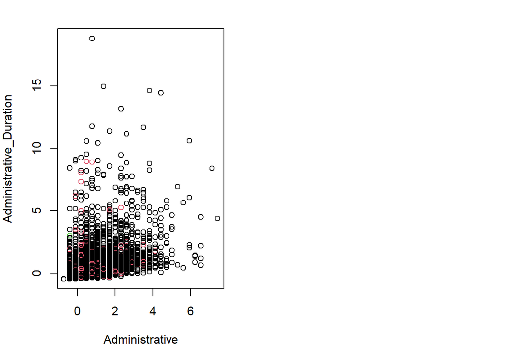

```r
par(mfrow = c(1,2), mar = c(5,4,2,2))
plot(std.ecommerce_new[,1:2], col=results$cluster)
par(mfrow = c(2,2), mar = c(5,4,2,2))
```

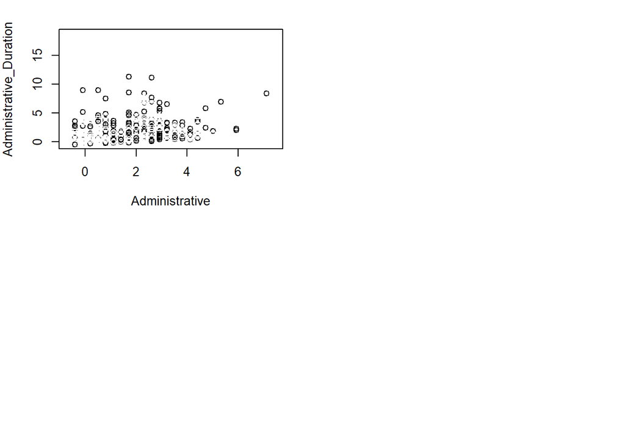

```r
plot(std.ecommerce_new[,1:2], col=ecommerce.class)
```

2. Information and Informational Duration

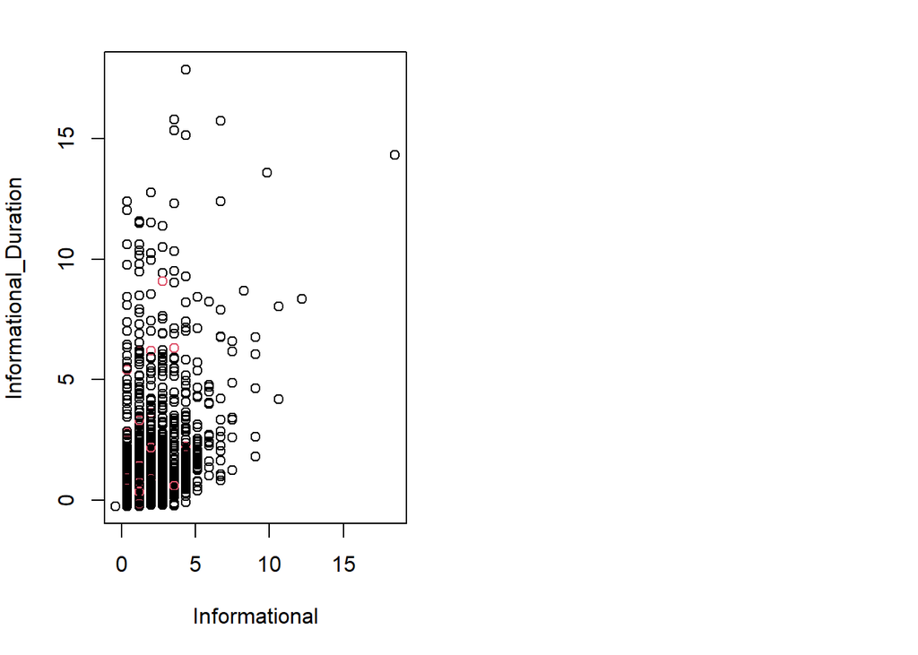

```r
par(mfrow = c(1,2), mar = c(5,4,2,2))
plot(std.ecommerce_new[,3:4], col=results$cluster)
par(mfrow = c(2,2), mar = c(5,4,2,2))
```

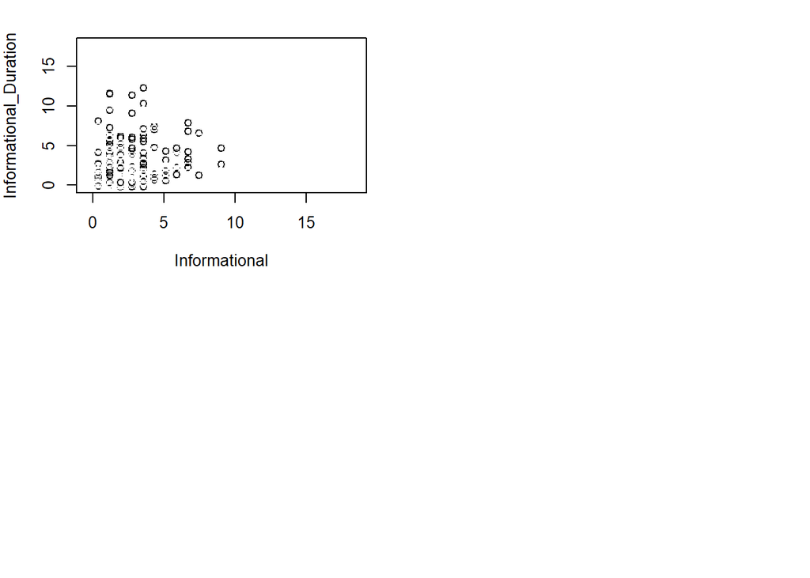

```r
plot(std.ecommerce_new[,3:4], col=ecommerce.class)
```

3. Product Related and Product Related Duration.

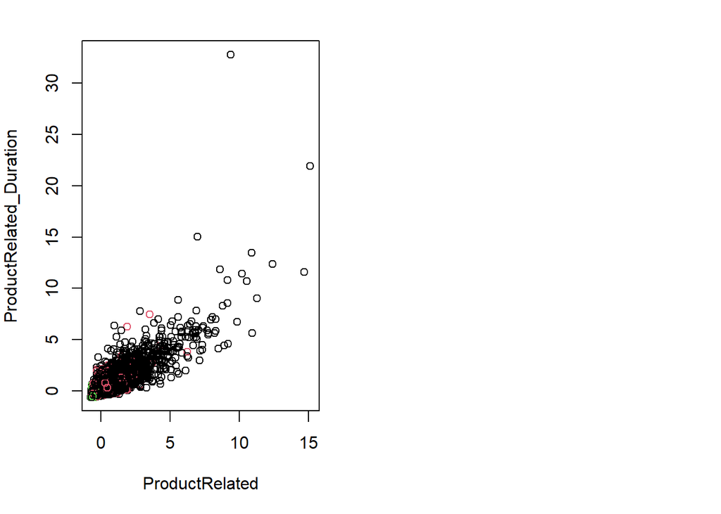

```r
par(mfrow = c(1,2), mar = c(5,4,2,2))
plot(std.ecommerce_new[,5:6], col=results$cluster)
par(mfrow = c(2,2), mar = c(5,4,2,2))
```

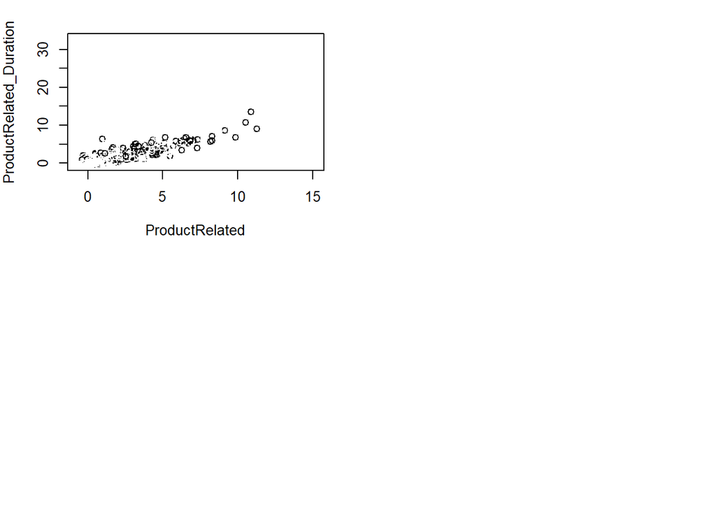

```r
plot(std.ecommerce_new[,5:6], col=ecommerce.class)
```

4. Bounce rates and Exit Rates distributed in Clusters

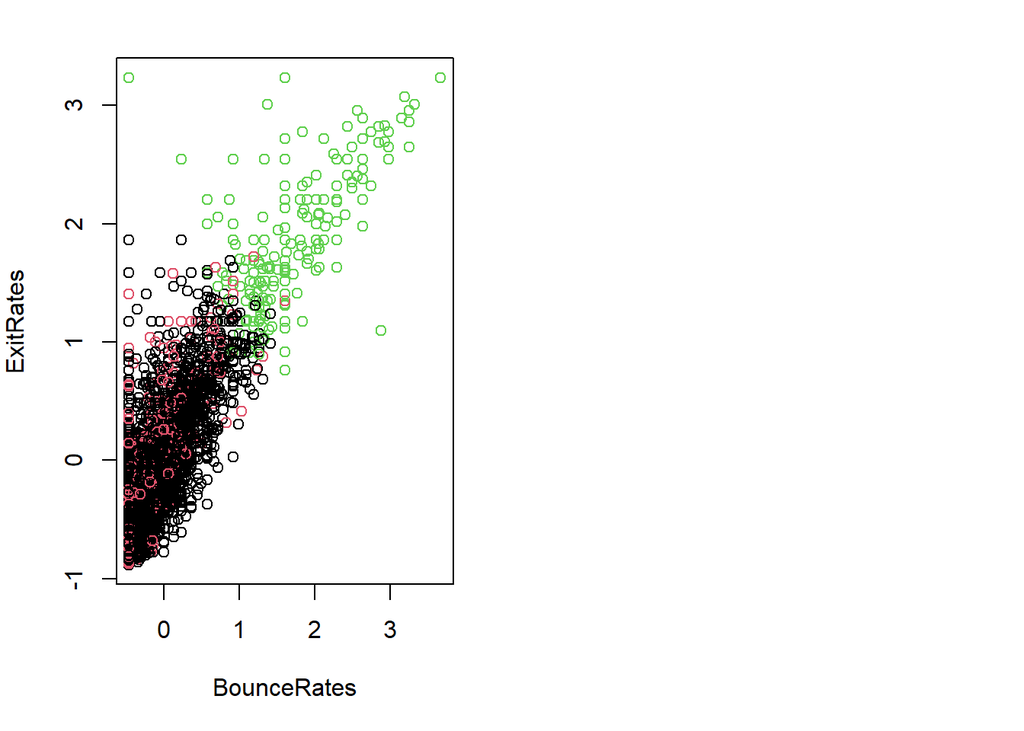

```r
par(mfrow = c(1,2), mar = c(5,4,2,2))
plot(std.ecommerce_new[,7:8], col=results$cluster)
par(mfrow = c(2,2), mar = c(5,4,2,2))
```

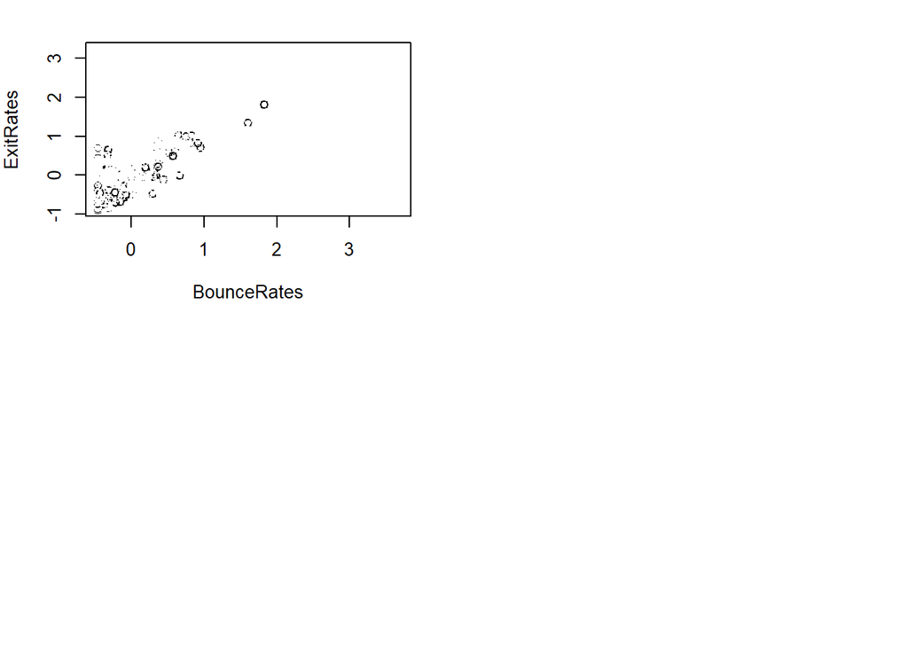

```r
plot(std.ecommerce_new[,7:8], col=ecommerce.class)
```